[figure not shown]

# Informe Amparos

CDD

16-10-2025

# **Objetivo**

El presente trabajo tiene como objetivo analizar el comportamiento de los socios que poseen amparos, focalizándonos en aquellos cuyo producto principal corresponde a **Medicamentos de Alta Complejidad- MAC**. En una primera instancia se realizará un análisis descriptivo de esta población, con el propósito de comprender su composición y características principales. Posteriormente, se examinarán los patrones de consumo observados durante el período comprendido entre **202304** y **202509**, a fin de identificar los medicamentos de alto consumo.

# **Fuente de datos**

La base de datos utilizada en este análisis fueron del sistema **JXNET** de legales (Amparos) y los consumos actualizados a valores de septiembre 2025 (**SITUACION_ACTUAL_202509**- DATAMART).

# **Descriptivo**

Los amparos con producto **Medicamentos de Alta Complejidad- MAC** representan el **2.16%** del total.

Comenzamos con un universo de 580 socios MAC. De estos, 58 socios fallecieron, por lo que fueron excluidos del estudio.

De los 522 socios restantes nos enfocamos en los 476 socios que se encuentran en la cartera activa. Los 46 socios con cartera no activa fueron excluidos por no cumplir con los criterios de inclusión del estudio.

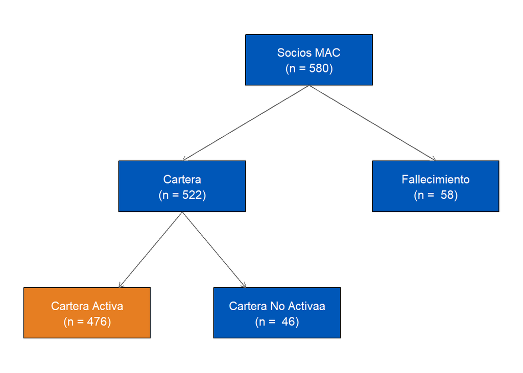

#### Socios con consumos en el período analizado

El siguiente gráfico nos indica la cantidad de socios que consumieron medicamentos en un decil determinado. (El decil fue calculado según el importe agrupado por monodroga). Podemos obervar que el decil con mayor socios es el 10 y un poco mas atras el 4, 5 y 9.

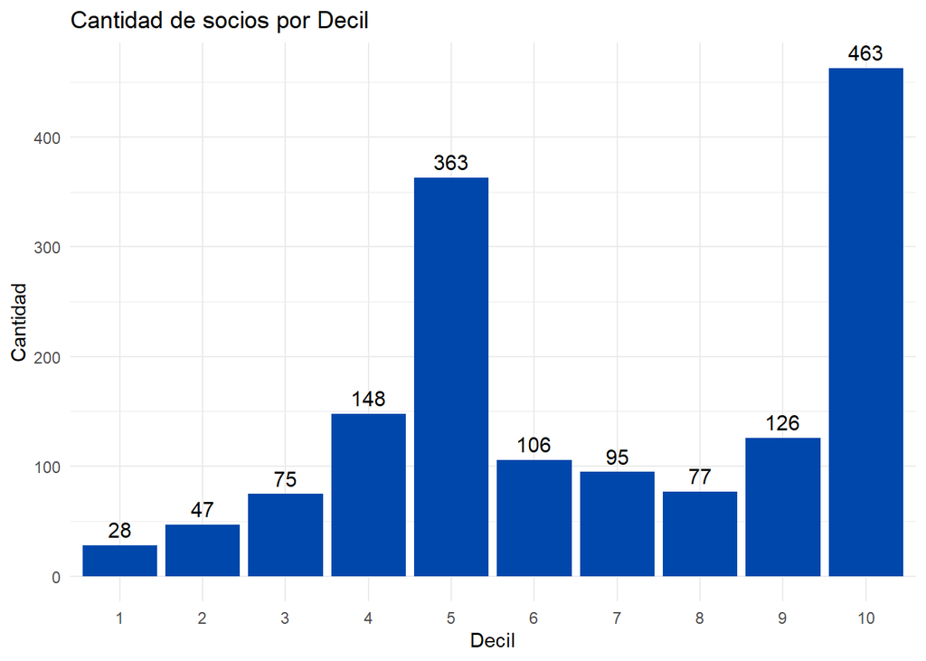

De la misma forma se gráfico el importe promedio por socio (en millones de $). Se observa que el mayor promedio se encuentra en el decil 10 y mas atras el decil 9.

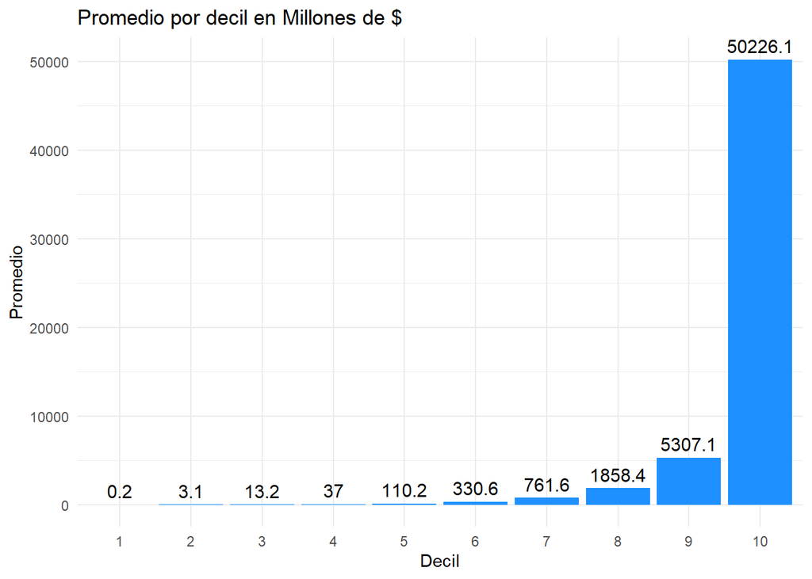

#### ¿Cuales son esos medicamentos?

Top 10 Medicamentos

| DDES_MONODROGA | NUM_VALOR_ACTUALIZADO_EN_MILL | CANTIDAD_DE_SOCIOS | MESES_PROMEDIO_CONSUMO | NUM_VALOR_ACTUALIZADO_MENSUALIZADO_MILL | MIN_IMPORTE_FINAL_CON_NOTA_CREDITO |
| --- | --- | --- | --- | --- | --- |
| VOSORITIDE | 7582.049 | 11 | 4.36 | 158.091092 | NA |
| BUROSUMAB | 7447.908 | 7 | 11.57 | 91.960834 | 35.197933 |
| TRASTUZUMAB DERUXTECÁN | 5200.114 | 30 | 6.57 | 26.383127 | 4.689391 |
| ATALUREN | 5046.759 | 4 | 5.25 | 240.321839 | NA |
| NA | 4706.206 | 302 | 4.49 | 3.470705 | NA |
| NUSINERSEN | 3456.390 | 11 | 5.82 | 53.989228 | 51.065523 |
| TREPROSTINIL | 2740.868 | 9 | 8.89 | 34.256572 | 132.092602 |
| RISDIPLAM | 2443.002 | 6 | 11.00 | 37.015180 | 11.161062 |
| TRASTUZUMAB EMTANSINA | 1851.810 | 10 | 7.40 | 25.024458 | 9.195193 |
| PERTUZUMAB+TRASTUZUMAB | 1580.698 | 11 | 7.91 | 18.166858 | 19.131834 |